# Solución — Clase 18

Variables categóricas, distancia χ² e inercia

**Código**

```r
library(tidyverse)
library(knitr)
source("../FuncionesCorrespondencias.R")
tabla <- margin.table(HairEyeColor, c(1, 2))
resumen <- resumir_tabla_contingencia(tabla)
```

## 1. Anatomía de la tabla

*Teoría relacionada: tabla de contingencia y perfiles fila y columna.*

**Código**

```r
kable(resumen$frecuencias)
```

|  | Brown | Blue | Hazel | Green |
| --- | --- | --- | --- | --- |
| Black | 68 | 20 | 15 | 5 |
| Brown | 119 | 84 | 54 | 29 |
| Red | 26 | 17 | 14 | 14 |
| Blond | 7 | 94 | 10 | 16 |

**Código**

```r
kable(round(resumen$proporciones, 3))
```

|  | Brown | Blue | Hazel | Green |
| --- | --- | --- | --- | --- |
| Black | 0.115 | 0.034 | 0.025 | 0.008 |
| Brown | 0.201 | 0.142 | 0.091 | 0.049 |
| Red | 0.044 | 0.029 | 0.024 | 0.024 |
| Blond | 0.012 | 0.159 | 0.017 | 0.027 |

**Código**

```r
kable(round(resumen$perfiles_fila, 3))
```

|  | Brown | Blue | Hazel | Green |
| --- | --- | --- | --- | --- |
| Black | 0.630 | 0.185 | 0.139 | 0.046 |
| Brown | 0.416 | 0.294 | 0.189 | 0.101 |
| Red | 0.366 | 0.239 | 0.197 | 0.197 |
| Blond | 0.055 | 0.740 | 0.079 | 0.126 |

**Código**

```r
kable(round(resumen$perfiles_columna, 3))
```

|  | Brown | Blue | Hazel | Green |
| --- | --- | --- | --- | --- |
| Black | 0.309 | 0.093 | 0.161 | 0.078 |
| Brown | 0.541 | 0.391 | 0.581 | 0.453 |
| Red | 0.118 | 0.079 | 0.151 | 0.219 |
| Blond | 0.032 | 0.437 | 0.108 | 0.250 |

**Código**

```r
kable(resumen$masas_fila, digits = 3)
```

| categoria | masa |
| --- | --- |
| Black | 0.182 |
| Brown | 0.483 |
| Red | 0.120 |
| Blond | 0.215 |

**Código**

```r
kable(resumen$masas_columna, digits = 3)
```

| categoria | masa |
| --- | --- |
| Brown | 0.372 |
| Blue | 0.363 |
| Hazel | 0.157 |
| Green | 0.108 |

**Código**

```r
c(suma_masas_fila = sum(resumen$masas_fila$masa), suma_masas_columna = sum(resumen$masas_columna$masa))
```

```
   suma_masas_fila suma_masas_columna
                 1                  1
```

Las masas describen peso global; los perfiles, composición condicional; las frecuencias mezclan ambas cosas.

## 2. Independencia

*Teoría relacionada: independencia y residuos $\chi^2$.*

**Código**

```r
kable(round(resumen$esperadas, 1))
```

|  | Brown | Blue | Hazel | Green |
| --- | --- | --- | --- | --- |
| Black | 40.1 | 39.2 | 17.0 | 11.7 |
| Brown | 106.3 | 103.9 | 44.9 | 30.9 |
| Red | 26.4 | 25.8 | 11.2 | 7.7 |
| Blond | 47.2 | 46.1 | 20.0 | 13.7 |

**Código**

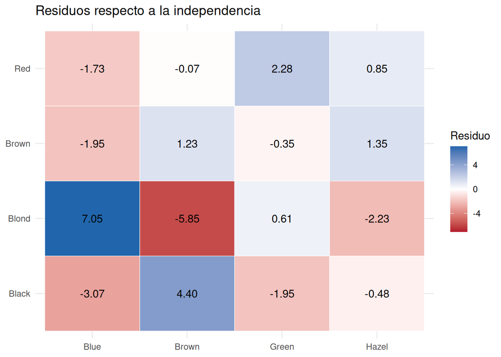

```r
visualizar_residuos_correspondencias(tabla)
```

**Código**

```r
residuos <- as.data.frame(as.table(resumen$residuos)) |>
  as_tibble() |> set_names(c("pelo", "ojos", "residuo")) |>
  arrange(desc(abs(residuo)))
kable(head(residuos, 6), digits = 3)
```

| pelo | ojos | residuo |
| --- | --- | --- |
| Blond | Blue | 7.050 |
| Blond | Brown | -5.851 |
| Black | Brown | 4.398 |
| Black | Blue | -3.069 |
| Red | Green | 2.283 |
| Blond | Hazel | -2.228 |

**Código**

```r
frecuencias_y_residuos <- as.data.frame(as.table(tabla)) |>
  as_tibble() |> set_names(c("pelo", "ojos", "frecuencia")) |>
  left_join(residuos, by = c("pelo", "ojos")) |>
  arrange(desc(frecuencia))
kable(head(frecuencias_y_residuos, 6), digits = 3)
```

| pelo | ojos | frecuencia | residuo |
| --- | --- | --- | --- |
| Brown | Brown | 119 | 1.233 |
| Blond | Blue | 94 | 7.050 |
| Brown | Blue | 84 | -1.949 |
| Black | Brown | 68 | 4.398 |
| Brown | Hazel | 54 | 1.353 |
| Brown | Green | 29 | -0.345 |

Una celda grande puede ser esperable por sus marginales y no caracterizar la dependencia.

## 3. Distancias

*Teoría relacionada: distancia $\chi^2$ entre perfiles.*

**Código**

```r
D_filas <- as.matrix(distancias_chi2(tabla, "filas"))
D_columnas <- as.matrix(distancias_chi2(tabla, "columnas"))
kable(round(D_filas, 3))
```

|  | Black | Brown | Red | Blond |
| --- | --- | --- | --- | --- |
| Black | 0.000 | 0.446 | 0.654 | 1.348 |
| Brown | 0.446 | 0.000 | 0.316 | 0.991 |
| Red | 0.654 | 0.316 | 0.000 | 1.043 |
| Blond | 1.348 | 0.991 | 1.043 | 0.000 |

**Código**

```r
kable(round(D_columnas, 3))
```

|  | Brown | Blue | Hazel | Green |
| --- | --- | --- | --- | --- |
| Brown | 0.000 | 1.040 | 0.398 | 0.784 |
| Blue | 1.040 | 0.000 | 0.806 | 0.579 |
| Hazel | 0.398 | 0.806 | 0.000 | 0.453 |
| Green | 0.784 | 0.579 | 0.453 | 0.000 |

**Código**

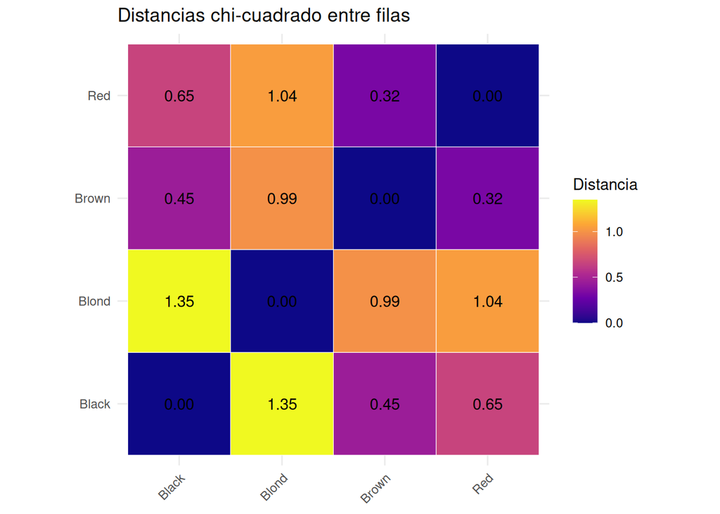

```r
visualizar_distancias_chi2(tabla, "filas")
```

**Código**

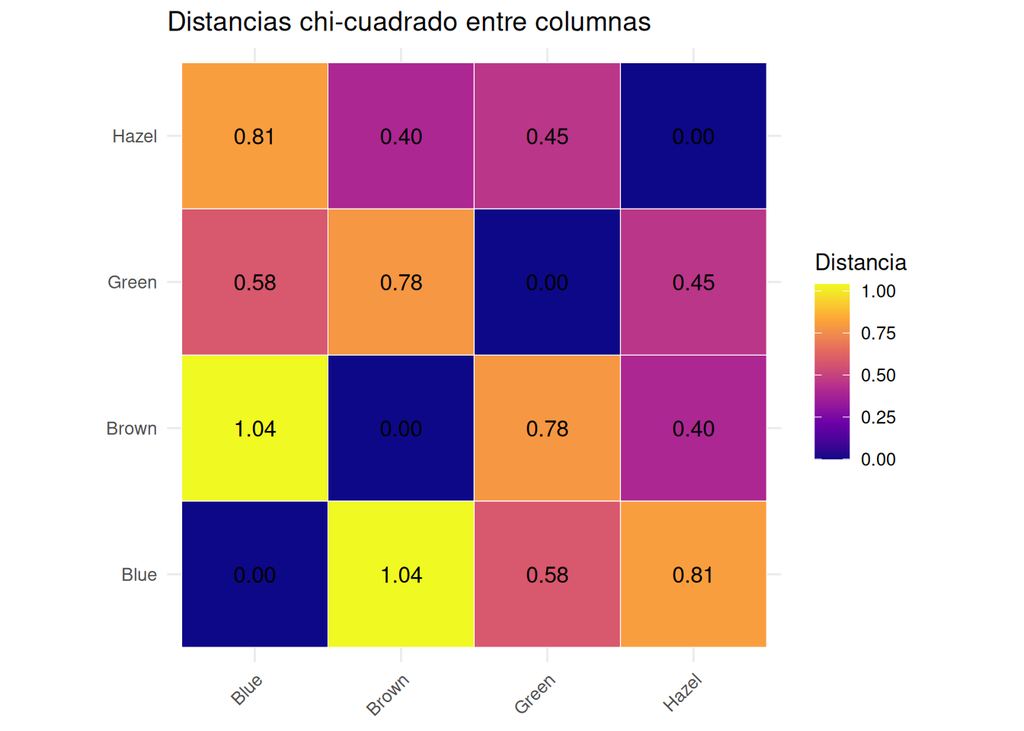

```r
visualizar_distancias_chi2(tabla, "columnas")
```

**Código**

```r
i <- "Black"; h <- "Brown"
perfiles <- resumen$perfiles_fila
masas <- resumen$masas_columna$masa
c(
  manual = sqrt(sum((perfiles[i, ] - perfiles[h, ])^2 / masas)),
  funcion = D_filas[i, h]
)
```

```
   manual   funcion
0.4461923 0.4461923
```

La ponderación aumenta la importancia relativa de diferencias en categorías columna poco frecuentes.

## 4. Tamaño frente a intensidad

*Teoría relacionada: inercia total y diferencia entre tamaño y asociación.*

**Código**

```r
resumen_10 <- resumir_tabla_contingencia(10 * tabla)
kable(bind_rows(
  mutate(resumen$prueba_chi2, tabla = "Original"),
  mutate(resumen_10$prueba_chi2, tabla = "Frecuencias x 10")
), digits = 6)
```

| chi2 | gl | p_valor | inercia | tabla |
| --- | --- | --- | --- | --- |
| 138.2898 | 9 | 0 | 0.233598 | Original |
| 1382.8984 | 9 | 0 | 0.233598 | Frecuencias x 10 |

**Código**

```r
max(abs(resumen$perfiles_fila - resumen_10$perfiles_fila))
```

```
[1] 0
```

**Código**

```r
max(abs(as.matrix(distancias_chi2(tabla)) - as.matrix(distancias_chi2(10 * tabla))))
```

```
[1] 0
```

Multiplicar los recuentos mantiene perfiles, distancias e inercia, pero multiplica $\chi^2$ y hace el p-valor más extremo.

## 5. Categoría rara

*Teoría relacionada: categorías raras y puntos extremos.*

**Código**

```r
tabla_rara <- rbind(tabla, Muy_raro = c(0, 1, 0, 2))
resumen_raro <- resumir_tabla_contingencia(tabla_rara)
kable(round(resumen_raro$perfiles_fila, 3))
```

|  | Brown | Blue | Hazel | Green |
| --- | --- | --- | --- | --- |
| Black | 0.630 | 0.185 | 0.139 | 0.046 |
| Brown | 0.416 | 0.294 | 0.189 | 0.101 |
| Red | 0.366 | 0.239 | 0.197 | 0.197 |
| Blond | 0.055 | 0.740 | 0.079 | 0.126 |
| Muy_raro | 0.000 | 0.333 | 0.000 | 0.667 |

**Código**

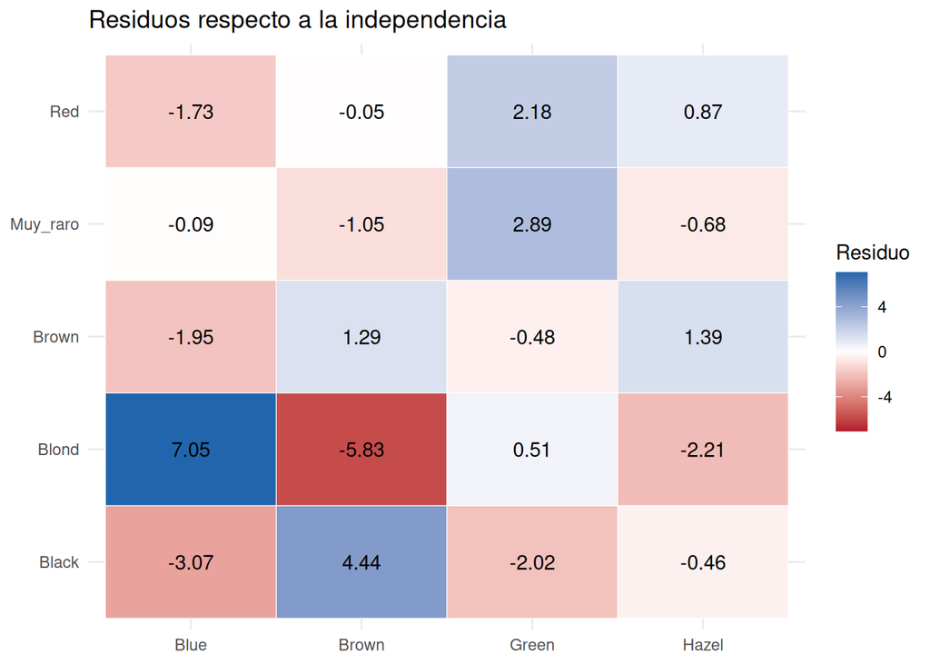

```r
visualizar_residuos_correspondencias(tabla_rara)
```

**Código**

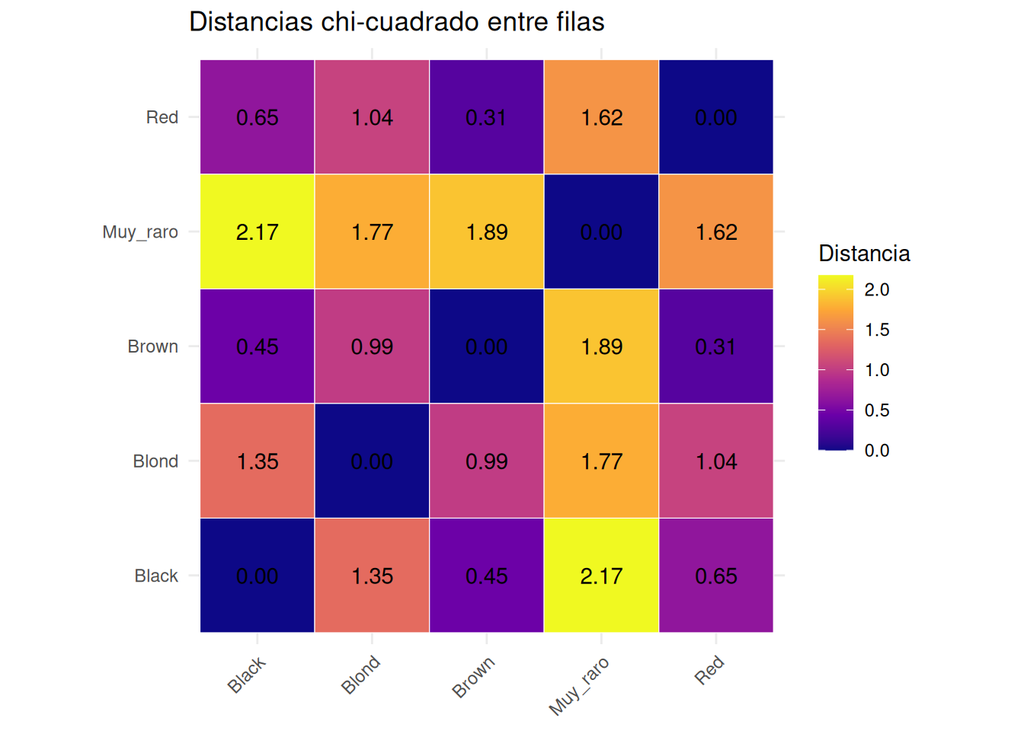

```r
visualizar_distancias_chi2(tabla_rara, "filas")
```

La nueva fila puede quedar extrema por solo tres observaciones. Antes de interpretarla hay que comunicar masa, recuento y estabilidad.

## 6. Decisión

*Teoría relacionada: protocolo de decisión y errores frecuentes.*

La asociación principal contrapone combinaciones como pelo rubio–ojos azules y pelo negro–ojos marrones. Los residuos concretan excesos y defectos, mientras las distancias comparan perfiles completos. El p-valor depende fuertemente de $n$; la inercia no cambia al multiplicar todos los recuentos. Las categorías raras requieren especial cautela.